# Part I - Ford Gobike Data Exploration

## Introduction

> This document explores trip duration and other attributes for the fordgobike dataset.

## Preliminary Wrangling

```python
# import all packages and set plots to be embedded inline
import numpy as np
import pandas as pd
import matplotlib.pyplot as plt
import seaborn as sb
%matplotlib inline
```

```python
df = pd.read_csv('201902-fordgobike-tripdata.csv')
```

```python
#we explore the data
df.head()
```

|  | duration_sec | start_time | end_time | start_station_id | start_station_name | start_station_latitude | start_station_longitude | end_station_id | end_station_name | end_station_latitude | end_station_longitude | bike_id | user_type | member_birth_year | member_gender | bike_share_for_all_trip |
| --- | --- | --- | --- | --- | --- | --- | --- | --- | --- | --- | --- | --- | --- | --- | --- | --- |
| 0 | 52185 | 2019-02-28 17:32:10.1450 | 2019-03-01 08:01:55.9750 | 21.0 | Montgomery St BART Station (Market St at 2nd St) | 37.789625 | -122.400811 | 13.0 | Commercial St at Montgomery St | 37.794231 | -122.402923 | 4902 | Customer | 1984.0 | Male | No |
| 1 | 42521 | 2019-02-28 18:53:21.7890 | 2019-03-01 06:42:03.0560 | 23.0 | The Embarcadero at Steuart St | 37.791464 | -122.391034 | 81.0 | Berry St at 4th St | 37.775880 | -122.393170 | 2535 | Customer | NaN | NaN | No |
| 2 | 61854 | 2019-02-28 12:13:13.2180 | 2019-03-01 05:24:08.1460 | 86.0 | Market St at Dolores St | 37.769305 | -122.426826 | 3.0 | Powell St BART Station (Market St at 4th St) | 37.786375 | -122.404904 | 5905 | Customer | 1972.0 | Male | No |
| 3 | 36490 | 2019-02-28 17:54:26.0100 | 2019-03-01 04:02:36.8420 | 375.0 | Grove St at Masonic Ave | 37.774836 | -122.446546 | 70.0 | Central Ave at Fell St | 37.773311 | -122.444293 | 6638 | Subscriber | 1989.0 | Other | No |
| 4 | 1585 | 2019-02-28 23:54:18.5490 | 2019-03-01 00:20:44.0740 | 7.0 | Frank H Ogawa Plaza | 37.804562 | -122.271738 | 222.0 | 10th Ave at E 15th St | 37.792714 | -122.248780 | 4898 | Subscriber | 1974.0 | Male | Yes |

```python
df.shape
```

```
(183412, 16)
```

The dataset has 183412 rows and 16 columns.

```python
df.info()
```

```
<class 'pandas.core.frame.DataFrame'>
RangeIndex: 183412 entries, 0 to 183411
Data columns (total 16 columns):
duration_sec               183412 non-null int64
start_time                 183412 non-null object
end_time                   183412 non-null object
start_station_id           183215 non-null float64
start_station_name         183215 non-null object
start_station_latitude     183412 non-null float64
start_station_longitude    183412 non-null float64
end_station_id             183215 non-null float64
end_station_name           183215 non-null object
end_station_latitude       183412 non-null float64
end_station_longitude      183412 non-null float64
bike_id                    183412 non-null int64
user_type                  183412 non-null object
member_birth_year          175147 non-null float64
member_gender              175147 non-null object
bike_share_for_all_trip    183412 non-null object
dtypes: float64(7), int64(2), object(7)
memory usage: 22.4+ MB
```

The columns have different datatypes

```python
df.start_time = pd.to_datetime(df.start_time)
```

```python
df.end_time = pd.to_datetime(df.end_time)
```

The start time and end time columns are converted to datetime data type.

```python
df['age']=2019-df['member_birth_year']
```

Age column is created by subracting birth year from 2019 when the bike trips took place to make analysis better.

```python
df['duration_min'] = df['duration_sec'] / 60
```

Duration in minutes column is also created by dividing duration in seconds by 60 for better analysis.

```python
df.head(2)
```

|  | duration_sec | start_time | end_time | start_station_id | start_station_name | start_station_latitude | start_station_longitude | end_station_id | end_station_name | end_station_latitude | end_station_longitude | bike_id | user_type | member_birth_year | member_gender | bike_share_for_all_trip | age | duration_min |
| --- | --- | --- | --- | --- | --- | --- | --- | --- | --- | --- | --- | --- | --- | --- | --- | --- | --- | --- |
| 0 | 52185 | 2019-02-28 17:32:10.145 | 2019-03-01 08:01:55.975 | 21.0 | Montgomery St BART Station (Market St at 2nd St) | 37.789625 | -122.400811 | 13.0 | Commercial St at Montgomery St | 37.794231 | -122.402923 | 4902 | Customer | 1984.0 | Male | No | 35.0 | 869.750000 |
| 1 | 42521 | 2019-02-28 18:53:21.789 | 2019-03-01 06:42:03.056 | 23.0 | The Embarcadero at Steuart St | 37.791464 | -122.391034 | 81.0 | Berry St at 4th St | 37.775880 | -122.393170 | 2535 | Customer | NaN | NaN | No | NaN | 708.683333 |

The age and duration_min columns were created successfully.

```python
df.info()
```

```
<class 'pandas.core.frame.DataFrame'>
RangeIndex: 183412 entries, 0 to 183411
Data columns (total 18 columns):
duration_sec               183412 non-null int64
start_time                 183412 non-null datetime64[ns]
end_time                   183412 non-null datetime64[ns]
start_station_id           183215 non-null float64
start_station_name         183215 non-null object
start_station_latitude     183412 non-null float64
start_station_longitude    183412 non-null float64
end_station_id             183215 non-null float64
end_station_name           183215 non-null object
end_station_latitude       183412 non-null float64
end_station_longitude      183412 non-null float64
bike_id                    183412 non-null int64
user_type                  183412 non-null object
member_birth_year          175147 non-null float64
member_gender              175147 non-null object
bike_share_for_all_trip    183412 non-null object
age                        175147 non-null float64
duration_min               183412 non-null float64
dtypes: datetime64[ns](2), float64(9), int64(2), object(5)
memory usage: 25.2+ MB
```

The start_time and end_time columns were successfully converted to datetime datatype.

```python
df.nunique()
```

```
duration_sec                 4752
start_time                 183401
end_time                   183397
start_station_id              329
start_station_name            329
start_station_latitude        334
start_station_longitude       335
end_station_id                329
end_station_name              329
end_station_latitude          335
end_station_longitude         335
bike_id                      4646
user_type                       2
member_birth_year              75
member_gender                   3
bike_share_for_all_trip         2
age                            75
duration_min                 4752
dtype: int64
```

```python
df['member_gender'].unique()
```

```
array(['Male', nan, 'Other', 'Female'], dtype=object)
```

There are 3 genders in the dataset.

```python
df['user_type'].unique()
```

```
array(['Customer', 'Subscriber'], dtype=object)
```

There are 2 types of users.

```python
df.describe()
```

|  | duration_sec | start_station_id | start_station_latitude | start_station_longitude | end_station_id | end_station_latitude | end_station_longitude | bike_id | member_birth_year | age | duration_min |
| --- | --- | --- | --- | --- | --- | --- | --- | --- | --- | --- | --- |
| count | 183412.000000 | 183215.000000 | 183412.000000 | 183412.000000 | 183215.000000 | 183412.000000 | 183412.000000 | 183412.000000 | 175147.000000 | 175147.000000 | 183412.000000 |
| mean | 726.078435 | 138.590427 | 37.771223 | -122.352664 | 136.249123 | 37.771427 | -122.352250 | 4472.906375 | 1984.806437 | 34.193563 | 12.101307 |
| std | 1794.389780 | 111.778864 | 0.099581 | 0.117097 | 111.515131 | 0.099490 | 0.116673 | 1664.383394 | 10.116689 | 10.116689 | 29.906496 |
| min | 61.000000 | 3.000000 | 37.317298 | -122.453704 | 3.000000 | 37.317298 | -122.453704 | 11.000000 | 1878.000000 | 18.000000 | 1.016667 |
| 25% | 325.000000 | 47.000000 | 37.770083 | -122.412408 | 44.000000 | 37.770407 | -122.411726 | 3777.000000 | 1980.000000 | 27.000000 | 5.416667 |
| 50% | 514.000000 | 104.000000 | 37.780760 | -122.398285 | 100.000000 | 37.781010 | -122.398279 | 4958.000000 | 1987.000000 | 32.000000 | 8.566667 |
| 75% | 796.000000 | 239.000000 | 37.797280 | -122.286533 | 235.000000 | 37.797320 | -122.288045 | 5502.000000 | 1992.000000 | 39.000000 | 13.266667 |
| max | 85444.000000 | 398.000000 | 37.880222 | -121.874119 | 398.000000 | 37.880222 | -121.874119 | 6645.000000 | 2001.000000 | 141.000000 | 1424.066667 |

### What is the structure of your dataset?

> There are 183412 fordgobike trips in the dataset with 16 columns; duration_sec, start_time, end_time, start_station_id, start_station_name, start_station_latitude, start_station_longitude, end_station_id, end_station_name, end_station_latitude ,end_station_longitude, bike_id, user_type, member_birth_year, member_gender and bike_share_for_all_trip. Two columns were also created for better analysis; age and duration_min.

### What is/are the main feature(s) of interest in your dataset?

> I am interested in showing how the trip duration is dependent on the other given attributes.

### What features in the dataset do you think will help support your investigation into your feature(s) of interest?

> Trip duration is likely to be dependent on age, start stations, end stations, user_type, gender and bike_share.

## Univariate Exploration

### We start by looking at the distribution of the trip duration in minutes.

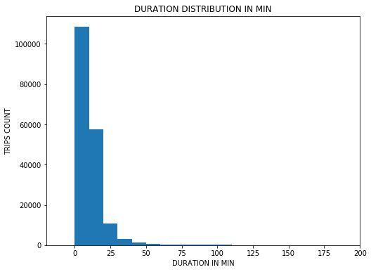

```python
binsize = 10
bins = np.arange(0, df['duration_min'].max()+binsize, binsize)
plt.figure(figsize=[8, 6])
plt.hist(data = df, x = 'duration_min', bins = bins)
plt.xlabel('DURATION IN MIN')
plt.ylabel('TRIPS COUNT')
plt.xlim(-20,200)
plt.title('DURATION DISTRIBUTION IN MIN')
plt.show()
```

A long tail in the distribution makes it hard to see the distribution, so lets put it on log scale.

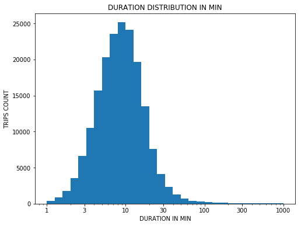

```python
#Log transforming to better understand the data
plt.figure(figsize=[8,6])
bins = 10**np.arange(0 , 3 + 0.1 , 0.1)
ticks =  [ 1 , 3, 10, 30, 100, 300, 1000]
labels = ['{}'.format(v) for v in ticks]
plt.hist(data = df, x = 'duration_min' , bins = bins);
plt.xscale('log');
plt.xticks(ticks,labels);
plt.xlabel('DURATION IN MIN');
plt.title('DURATION DISTRIBUTION IN MIN');
plt.ylabel('TRIPS COUNT');
```

Most of the values fall between 2 minutes and 20 minutes. Most riders' trip duration was between 2 and 20 minutes while few riders' duration was below 2 minutes and above 20 minutes.

Average Bike Trip Duration The average bike lasts between 1 and just over 100 minutes with the majority of bike trips lasting just under 10 minutes.

### Distribution of gender.

```
Text(0.5,1,'GENDER DISTRIBUTION')
```

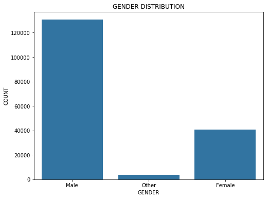

```python
plt.figure(figsize=[8,6])
base_color=sb.color_palette()[0]
sb.countplot(data=df,x='member_gender',color=base_color);
plt.xlabel('GENDER')
plt.ylabel('COUNT')
plt.title('GENDER DISTRIBUTION')
```

There are more male riders in the trip compared to other and female genders.

### Distribution of user type.

```
Text(0.5,1,'USER TYPE DISTRIBUTION')
```

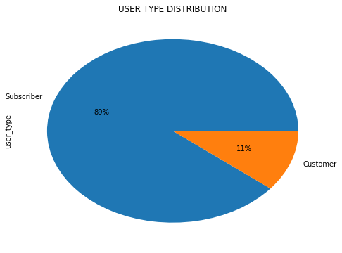

```python
#create the percent function
def percent(value):
    percent=round(df[value].value_counts()/len(df)*100)
    return percent
#returns a pie chart with percentages
value=percent('user_type')
df['user_type'].value_counts().plot(kind='pie',autopct='%1.0f%%',figsize=(8,6)) #%1.0f%% returns a percentage in a whole number without decimal points.
plt.title('USER TYPE DISTRIBUTION')
```

There were more subcribers than the customers in the trip.

### Distribution of bike share.

```
Text(0.5,1,'BIKE SHARE DISTRIBUTION')
```

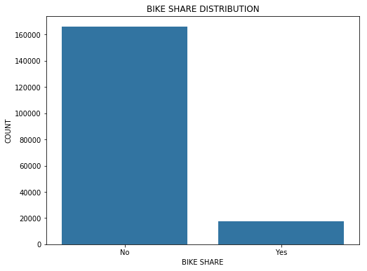

```python
plt.figure(figsize=[8,6])
base_color=sb.color_palette()[0]
sb.countplot(data=df,x='bike_share_for_all_trip',color=base_color);
plt.xlabel('BIKE SHARE')
plt.ylabel('COUNT')
plt.title('BIKE SHARE DISTRIBUTION')
```

Most riders did not share their bikes

### Distribution of start station ids.

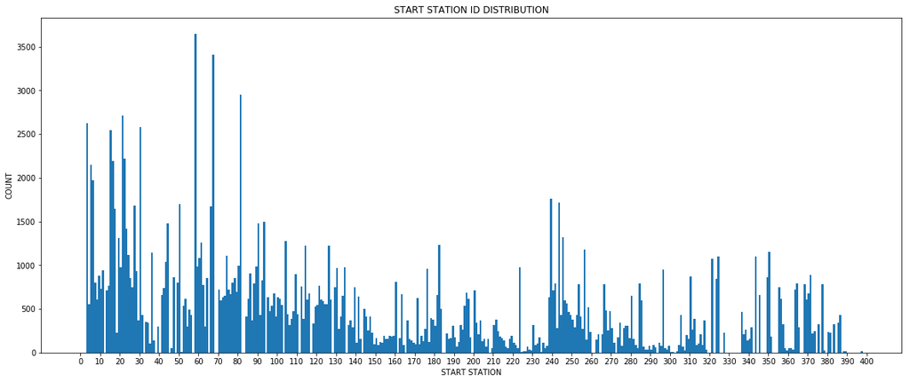

```python
# Plotting start station id distribution.
binsize = 1
bins = np.arange(0, df['start_station_id'].astype(float).max()+binsize, binsize)
plt.figure(figsize=[20, 8])
plt.xticks(range(0, 410, 10))
plt.hist(data = df.dropna(), x = 'start_station_id', bins = bins)
plt.title('START STATION ID DISTRIBUTION')
plt.xlabel('START STATION')
plt.ylabel('COUNT')
plt.show()
```

### Distribution of end station ids.

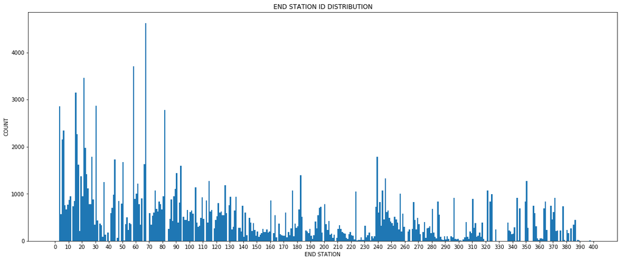

```python
# Plotting end station id distribution.
binsize = 1
bins = np.arange(0, df['end_station_id'].astype(float).max()+binsize, binsize)
plt.figure(figsize=[20, 8])
plt.xticks(range(0, 410, 10))
plt.hist(data = df.dropna(), x = 'end_station_id', bins = bins)
plt.title('END STATION ID DISTRIBUTION')
plt.xlabel('END STATION')
plt.ylabel('COUNT')
plt.show()
```

### Distribution of start station names

```python
df['start_station_name'].value_counts()
```

```
Market St at 10th St                                               3904
San Francisco Caltrain Station 2  (Townsend St at 4th St)          3544
Berry St at 4th St                                                 3052
Montgomery St BART Station (Market St at 2nd St)                   2895
Powell St BART Station (Market St at 4th St)                       2760
San Francisco Ferry Building (Harry Bridges Plaza)                 2710
San Francisco Caltrain (Townsend St at 4th St)                     2703
Powell St BART Station (Market St at 5th St)                       2327
Howard St at Beale St                                              2293
Steuart St at Market St                                            2283
The Embarcadero at Sansome St                                      2082
Bancroft Way at Telegraph Ave                                      1796
Bancroft Way at College Ave                                        1770
2nd St at Townsend St                                              1765
3rd St at Townsend St                                              1753
Embarcadero BART Station (Beale St at Market St)                   1746
Beale St at Harrison St                                            1719
Civic Center/UN Plaza BART Station (Market St at McAllister St)    1611
Townsend St at 7th St                                              1573
4th St at Mission Bay Blvd S                                       1552
The Embarcadero at Steuart St                                      1458
Post St at Kearny St                                               1376
Downtown Berkeley BART                                             1375
4th St at 16th St                                                  1360
Howard St at 8th St                                                1314
Rhode Island St at 17th St                                         1303
Esprit Park                                                        1290
19th Street BART Station                                           1276
Hearst Ave at Euclid Ave                                           1203
8th St at Brannan St                                               1203
                                                                   ...
Mendell St at Fairfax Ave                                            57
27th St at MLK Jr Way                                                55
45th St at MLK Jr Way                                                55
San Antonio Park                                                     53
Delmas Ave and San Fernando St                                       50
Williams Ave at 3rd St                                               50
Locust St at Grant St                                                49
San Carlos St at Market St                                           48
Lane St at Revere Ave                                                36
Foothill Blvd at Harrington Ave                                      35
Almaden Blvd at Balbach St                                           34
Mission St at 1st St                                                 34
SAP Center                                                           32
George St at 1st St                                                  31
Oak St at 1st St                                                     30
Empire St at 7th St                                                  29
Williams Ave at Apollo St                                            25
Foothill Blvd at 42nd Ave                                            23
26th Ave at International Blvd                                       19
San Pedro St at Hedding St                                           19
Farnam St at Fruitvale Ave                                           18
23rd Ave at Foothill Blvd                                            18
Backesto Park (Jackson St at 13th St)                                17
Leavenworth St at Broadway                                           17
Taylor St at 9th St                                                  13
Willow St at Vine St                                                  9
Parker Ave at McAllister St                                           7
21st Ave at International Blvd                                        4
Palm St at Willow St                                                  4
16th St Depot                                                         2
Name: start_station_name, Length: 329, dtype: int64
```

```python
locs = ['Market St at 10th St','San Francisco Caltrain Station 2  (Townsend St at 4th St)','Berry St at 4th St','Montgomery St BART Station (Market St at 2nd St)','Powell St BART Station (Market St at 4th St)','San Francisco Ferry Building (Harry Bridges Plaza)','San Francisco Caltrain (Townsend St at 4th St)','Powell St BART Station (Market St at 5th St)','Howard St at Beale St','Steuart St at Market St']
top_stations=df.loc[df['start_station_name'].isin(locs)]
```

```python
top_stations['start_station_name'].value_counts()
```

```
Market St at 10th St                                         3904
San Francisco Caltrain Station 2  (Townsend St at 4th St)    3544
Berry St at 4th St                                           3052
Montgomery St BART Station (Market St at 2nd St)             2895
Powell St BART Station (Market St at 4th St)                 2760
San Francisco Ferry Building (Harry Bridges Plaza)           2710
San Francisco Caltrain (Townsend St at 4th St)               2703
Powell St BART Station (Market St at 5th St)                 2327
Howard St at Beale St                                        2293
Steuart St at Market St                                      2283
Name: start_station_name, dtype: int64
```

```python
type_counts = top_stations['start_station_name'].value_counts()
type_order = type_counts.index
```

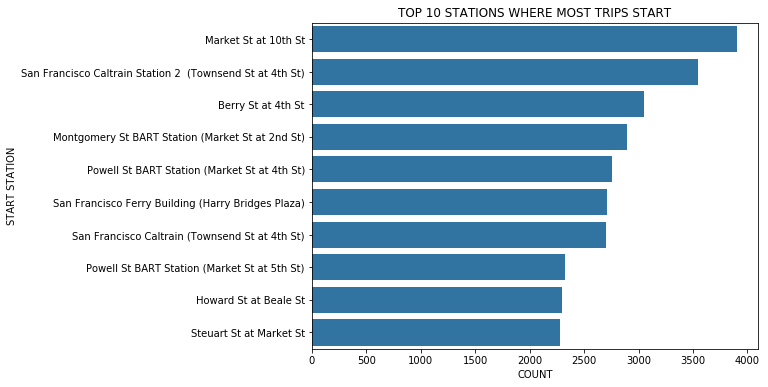

```python
plt.figure(figsize=[8,6])
base_color = sb.color_palette()[0]
sb.countplot(data=top_stations, y='start_station_name', color=base_color, order=type_order)
plt.xlabel('COUNT')
plt.ylabel('START STATION')
plt.title('TOP 10 STATIONS WHERE MOST TRIPS START');
```

Market St at 10th St start station is where most trips started.

### Distribution of end station names

```python
df['end_station_name'].value_counts()
```

```
San Francisco Caltrain Station 2  (Townsend St at 4th St)          4857
Market St at 10th St                                               3973
Montgomery St BART Station (Market St at 2nd St)                   3647
San Francisco Ferry Building (Harry Bridges Plaza)                 3368
Powell St BART Station (Market St at 4th St)                       2997
San Francisco Caltrain (Townsend St at 4th St)                     2947
Berry St at 4th St                                                 2872
The Embarcadero at Sansome St                                      2512
Powell St BART Station (Market St at 5th St)                       2353
Steuart St at Market St                                            2338
Howard St at Beale St                                              2034
Civic Center/UN Plaza BART Station (Market St at McAllister St)    1865
Bancroft Way at Telegraph Ave                                      1814
Beale St at Harrison St                                            1812
2nd St at Townsend St                                              1741
3rd St at Townsend St                                              1700
Embarcadero BART Station (Beale St at Market St)                   1699
4th St at Mission Bay Blvd S                                       1626
Townsend St at 7th St                                              1540
The Embarcadero at Steuart St                                      1447
19th Street BART Station                                           1430
Post St at Kearny St                                               1422
Downtown Berkeley BART                                             1380
Rhode Island St at 17th St                                         1345
8th St at Brannan St                                               1331
Folsom St at 3rd St                                                1302
Howard St at 8th St                                                1284
Esprit Park                                                        1266
4th St at 16th St                                                  1208
Spear St at Folsom St                                              1164
                                                                   ...
San Carlos St at Market St                                           52
Williams Ave at 3rd St                                               51
27th St at MLK Jr Way                                                49
Market St at 40th St                                                 49
Empire St at 1st St                                                  47
Lane St at Revere Ave                                                46
Locust St at Grant St                                                45
SAP Center                                                           42
Bestor Art Park                                                      38
Almaden Blvd at Balbach St                                           38
10th Ave at E 15th St                                                37
George St at 1st St                                                  34
San Pedro St at Hedding St                                           30
Oak St at 1st St                                                     28
Empire St at 7th St                                                  28
Mission St at 1st St                                                 25
Backesto Park (Jackson St at 13th St)                                21
Williams Ave at Apollo St                                            20
23rd Ave at Foothill Blvd                                            20
Foothill Blvd at 42nd Ave                                            20
Farnam St at Fruitvale Ave                                           20
26th Ave at International Blvd                                       19
Foothill Blvd at Harrington Ave                                      16
Leavenworth St at Broadway                                           12
Taylor St at 9th St                                                  11
Parker Ave at McAllister St                                           9
Palm St at Willow St                                                  7
16th St Depot                                                         6
21st Ave at International Blvd                                        6
Willow St at Vine St                                                  5
Name: end_station_name, Length: 329, dtype: int64
```

```python
loc=['San Francisco Caltrain Station 2  (Townsend St at 4th St)','Market St at 10th St','Montgomery St BART Station (Market St at 2nd St)','San Francisco Ferry Building (Harry Bridges Plaza)','Powell St BART Station (Market St at 4th St)','San Francisco Caltrain (Townsend St at 4th St)','Berry St at 4th St','The Embarcadero at Sansome St','Powell St BART Station (Market St at 5th St)','Steuart St at Market St']
top_end_stations=df.loc[df['end_station_name'].isin(locs)]
```

```python
top_end_stations['end_station_name'].value_counts()
```

```
San Francisco Caltrain Station 2  (Townsend St at 4th St)    4857
Market St at 10th St                                         3973
Montgomery St BART Station (Market St at 2nd St)             3647
San Francisco Ferry Building (Harry Bridges Plaza)           3368
Powell St BART Station (Market St at 4th St)                 2997
San Francisco Caltrain (Townsend St at 4th St)               2947
Berry St at 4th St                                           2872
Powell St BART Station (Market St at 5th St)                 2353
Steuart St at Market St                                      2338
Howard St at Beale St                                        2034
Name: end_station_name, dtype: int64
```

[figure not shown]

```python
type_counts = top_end_stations['end_station_name'].value_counts()
type_order = type_counts.index
plt.figure(figsize=[8,6])
base_color = sb.color_palette()[0]
sb.countplot(data=top_end_stations, y='end_station_name', color=base_color, order=type_order)
plt.xlabel('COUNT')
plt.ylabel('END STATION')
plt.title('TOP 10 STATIONS WHERE MOST TRIPS END');
```

San Francisco Caltrain Station 2 (Townsend St at 4th St) is where most trips ended.

### Distribution of age

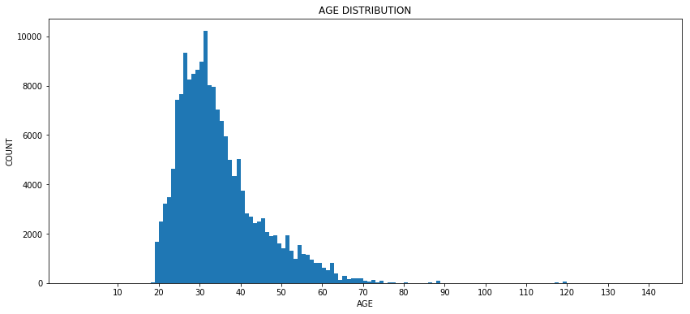

```python
# Plotting age distribution
binsize = 1
bins = np.arange(0, df['age'].astype(float).max()+binsize, binsize)
plt.figure(figsize=[14,6])
plt.xticks(range(10, 150, 10))
plt.hist(data = df.dropna(), x = 'age', bins = bins)
plt.title('AGE DISTRIBUTION')
plt.xlabel('AGE')
plt.ylabel('COUNT')
plt.show()
```

Most riders are between 20 years and 40 years.

## Bivariate Exploration

### How trip duration depend on age.

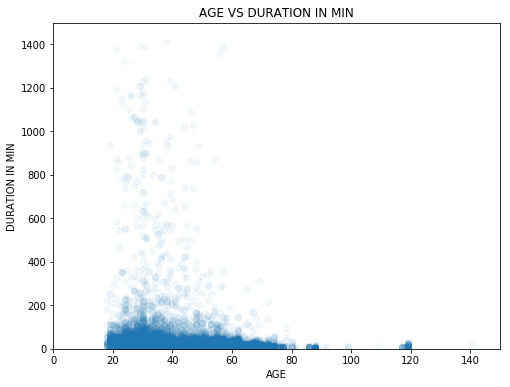

```python
plt.figure(figsize=[8,6])
plt.scatter(data=df,x='age',y='duration_min',alpha=1/20);
plt.axis([0, 150, 0, 1500])
plt.xlabel('AGE')
plt.ylabel('DURATION IN MIN')
plt.title('AGE VS DURATION IN MIN')
plt.show()
```

The graph above can not tell how the variables are related. We crop the graph by using lesser samples.

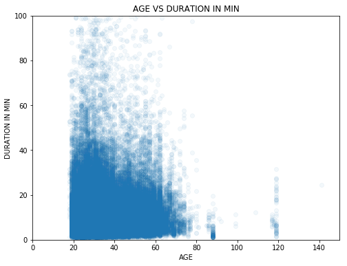

```python
plt.figure(figsize=[8,6])
plt.scatter(data=df,x='age',y='duration_min',alpha=1/20);
plt.axis([0, 150, 0, 100])
plt.xlabel('AGE')
plt.ylabel('DURATION IN MIN')
plt.title('AGE VS DURATION IN MIN')
plt.show()
```

Most riders are aged between 20 years and 50 years and most younger riders have longer trips.

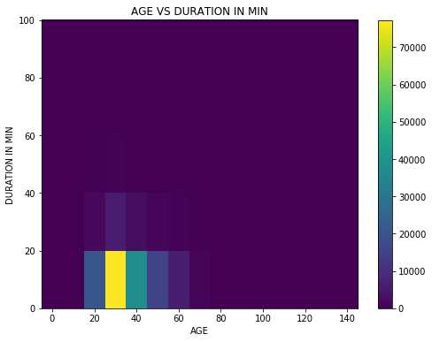

```python
plt.figure(figsize=[8,6])
bins_x = np.arange(-5, 145+1, 10)
bins_y = np.arange(0, 100+1, 20)
plt.hist2d((df['age']), df['duration_min'],bins = [bins_x, bins_y])
plt.colorbar();
plt.xlabel('AGE')
plt.ylabel('DURATION IN MIN')
plt.title('AGE VS DURATION IN MIN')
plt.show()
```

The 2d histogram above also shows that most riders are aged between 20 years and 50 years and most younger riders have longer trips

### How trip duration depend on gender.

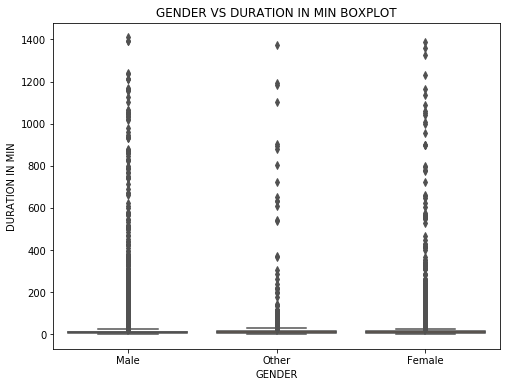

```python
plt.figure(figsize = [8, 6])
base_color = sb.color_palette()[1]
sb.boxplot(data = df, x = 'member_gender', y = 'duration_min', color = base_color)
plt.xlabel('GENDER')
plt.ylabel('DURATION IN MIN')
plt.title('GENDER VS DURATION IN MIN BOXPLOT')
plt.show()
```

The boxplots above are not clear to the variables correlation.

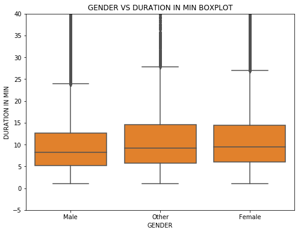

```python
plt.figure(figsize = [8, 6])
base_color = sb.color_palette()[1]
sb.boxplot(data = df, x = 'member_gender', y = 'duration_min', color = base_color)
plt.ylim([-5, 40])
plt.xlabel('GENDER')
plt.ylabel('DURATION IN MIN')
plt.title('GENDER VS DURATION IN MIN BOXPLOT')
plt.show()
```

We used trips which took 40 minutes and below to see the relationship between trip duration and gender. The boxplot shows that the other and female genders took longer trips compared to male.

### How trip duration depend on user type.

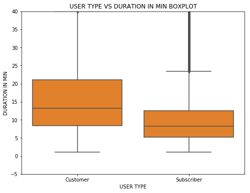

```python
plt.figure(figsize = [8, 6])
base_color = sb.color_palette()[1]
sb.boxplot(data = df, x = 'user_type', y = 'duration_min', color = base_color)
plt.ylim([-5, 40])
plt.xlabel('USER TYPE')
plt.ylabel('DURATION IN MIN')
plt.title('USER TYPE VS DURATION IN MIN BOXPLOT')
plt.show()
```

The boxplot shows that Customers had longer trips compared to the subscribers.

### How trip duration depend on bike share

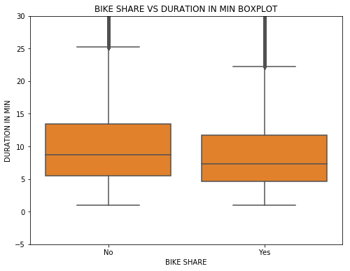

```python
plt.figure(figsize = [8, 6])
base_color = sb.color_palette()[1]
sb.boxplot(data = df, x = 'bike_share_for_all_trip', y = 'duration_min', color = base_color)
plt.ylim([-5, 30])
plt.xlabel('BIKE SHARE')
plt.ylabel('DURATION IN MIN')
plt.title('BIKE SHARE VS DURATION IN MIN BOXPLOT')
plt.show()
```

The boxplot shows that riders who did not share bikes had longer trips duration compared to the ones who shared.

### How trip duration depend on start station id.

```python
df_list = []
all_start_station_ids = sorted(df.start_station_id.unique())
for x in all_start_station_ids :
    df_list.append(df[df.start_station_id == x].duration_min.mean())
average_duration = pd.Series(df_list)
```

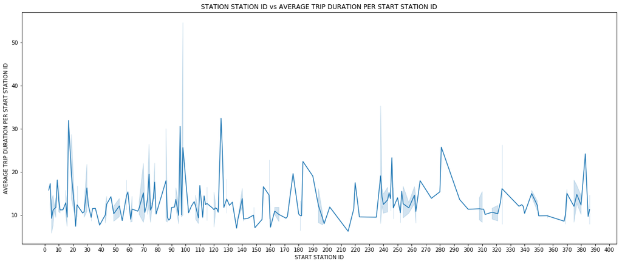

```python
plt.figure(figsize = [20, 8])
sb.lineplot(x = df['start_station_id'], y = average_duration)
plt.xticks(range(0, 410, 10))
plt.xlabel('START STATION ID')
plt.ylabel('AVERAGE TRIP DURATION PER START STATION ID')
plt.title('STATION STATION ID vs AVERAGE TRIP DURATION PER START STATION ID')
plt.show()
```

```python
df_list = []
all_start_station_ids = sorted(df.start_station_id.unique())
for x in all_start_station_ids :
    df_list.append(df[df.start_station_id == x].duration_min.sum())
total_duration = pd.Series(df_list)
```

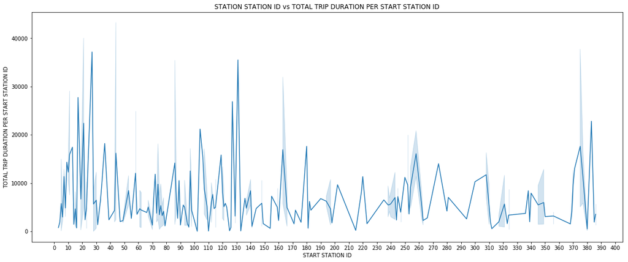

```python
plt.figure(figsize = [20, 8])
sb.lineplot(x = df['start_station_id'], y = total_duration)
plt.xticks(range(0, 410, 10))
plt.xlabel('START STATION ID')
plt.ylabel('TOTAL TRIP DURATION PER START STATION ID')
plt.title('STATION STATION ID vs TOTAL TRIP DURATION PER START STATION ID')
plt.show()
```

### How trip duration depend on end station id.

```python
df_list = []
all_end_station_ids = sorted(df.end_station_id.unique())
for x in all_end_station_ids :
    df_list.append(df[df.end_station_id == x].duration_min.mean())
average_duration = pd.Series(df_list)
```

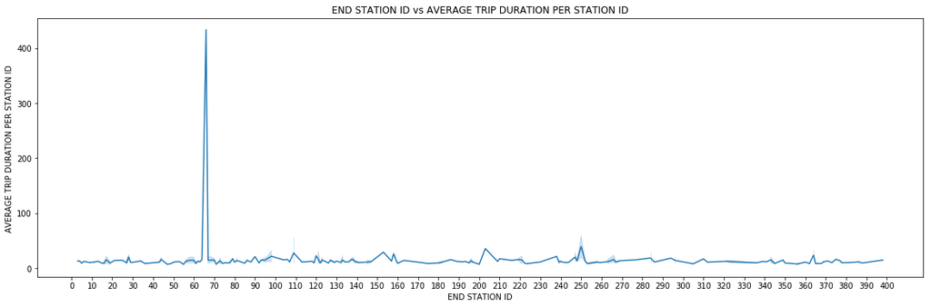

```python
plt.figure(figsize = [20, 6])
sb.lineplot(x = df['end_station_id'], y = average_duration)
plt.xticks(range(0, 410, 10))
plt.xlabel('END STATION ID')
plt.ylabel('AVERAGE TRIP DURATION PER STATION ID ')
plt.title('END STATION ID vs AVERAGE TRIP DURATION PER STATION ID')
plt.show()
```

```python
avg_duration_per_end_station_id=df.groupby('end_station_id').mean().duration_min
```

```python
avg_duration_per_end_station_id
```

```
end_station_id
3.0      12.577122
4.0      14.575972
5.0      13.038447
6.0      17.589557
7.0      10.074207
8.0      18.305701
9.0      13.521446
10.0     17.010103
11.0     14.190356
13.0     14.927203
14.0     14.059793
15.0     13.908704
16.0     11.249423
17.0     11.495664
18.0     12.659105
19.0     13.519292
20.0     14.848461
21.0     11.980710
22.0     11.326811
23.0     10.938897
24.0     13.071879
25.0     12.752615
26.0     10.876274
27.0      9.553523
28.0     11.869672
29.0     29.166210
30.0     10.104485
31.0     18.720300
33.0     16.284804
34.0     19.985608
           ...
350.0     9.773303
351.0    13.647292
355.0    15.821792
356.0    11.654827
357.0     9.419235
358.0    29.218301
359.0    17.097500
360.0    22.765860
```

[output cut: 8 more lines]

```
371.0    31.664002
372.0     8.957433
373.0    17.387054
375.0    28.273207
377.0    35.659944
378.0    21.031548
380.0    26.662806
381.0    14.329714
383.0    14.636111
385.0     9.741644
386.0    10.931129
388.0    30.500000
389.0    17.004545
398.0    10.143056
Name: duration_min, Length: 329, dtype: float64
```

```python
avg_duration_per_end_station_id.describe()
```

```
count    329.000000
mean      14.337772
std       23.953360
min        5.964497
25%        9.591667
50%       11.444815
75%       14.323729
max      433.336111
Name: duration_min, dtype: float64
```

```python
df_list = []
all_end_station_ids = sorted(df.end_station_id.unique())
for x in all_end_station_ids :
    df_list.append(df[df.end_station_id == x].duration_min.sum())
total_duration = pd.Series(df_list)
```

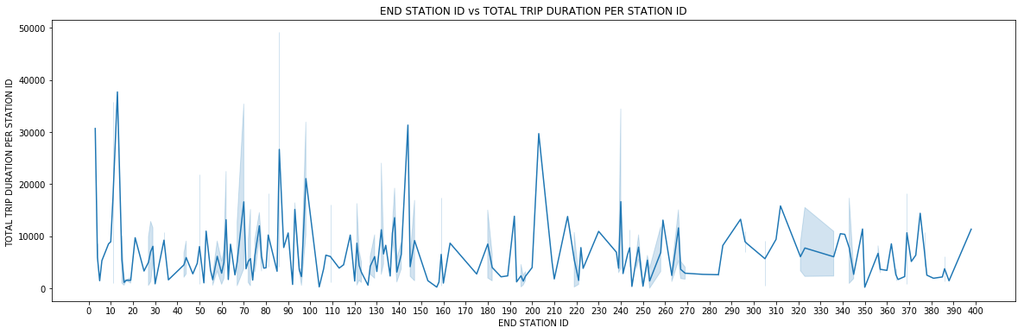

```python
plt.figure(figsize = [20, 6])
sb.lineplot(x = df['end_station_id'], y = total_duration)
plt.xticks(range(0, 410, 10))
plt.xlabel('END STATION ID')
plt.ylabel('TOTAL TRIP DURATION PER STATION ID ')
plt.title('END STATION ID vs TOTAL TRIP DURATION PER STATION ID')
plt.show()
```

### How gender and age depend on each other.

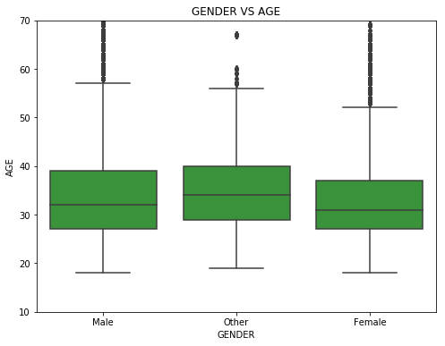

```python
plt.figure(figsize = [8, 6])
base_color = sb.color_palette()[2]
sb.boxplot(data = df, x = 'member_gender', y = 'age', color = base_color)
plt.ylim([10, 70])
plt.xlabel('GENDER')
plt.ylabel('AGE')
plt.title('GENDER VS AGE')
plt.show()
```

The boxplots show that the other gender have older people.

### How user type and age depend on each other

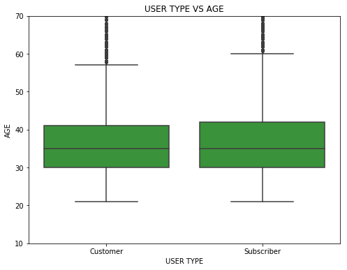

```python
plt.figure(figsize = [8, 6])
base_color = sb.color_palette()[2]
sb.boxplot(data = df, x = 'user_type', y = 'age', color = base_color)
plt.ylim([10, 70])
plt.xlabel('USER TYPE')
plt.ylabel('AGE')
plt.title('USER TYPE VS AGE')
plt.show()
```

The boxplots show that both customers and subscribers range on the same age.

### How bike share and age depend on each other.

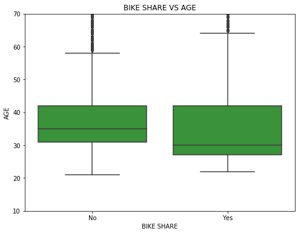

```python
plt.figure(figsize = [8, 6])
base_color = sb.color_palette()[2]
sb.boxplot(data = df, x = 'bike_share_for_all_trip', y = 'age', color = base_color)
plt.ylim([10, 70])
plt.xlabel('BIKE SHARE')
plt.ylabel('AGE')
plt.title('BIKE SHARE VS AGE')
plt.show()
```

The boxplots show that riders that did not share their bikes are older while the ones that shared their bikes are younger.

### How gender and user type depend on each other.

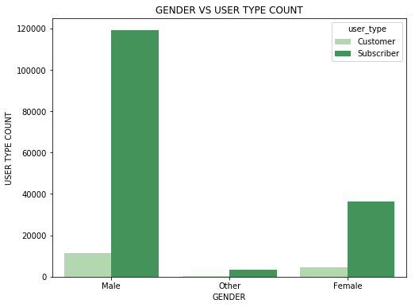

```python
plt.figure(figsize = [8, 6])
sb.countplot(data = df, x = 'member_gender', hue = 'user_type', palette = 'Greens')
plt.xlabel('GENDER')
plt.ylabel('USER TYPE COUNT')
plt.title('GENDER VS USER TYPE COUNT')
plt.show()
```

Most riders in all genders are subscribers.

### How gender and bike share depend on each other.

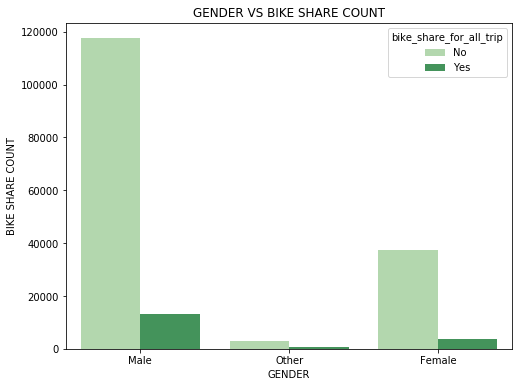

```python
plt.figure(figsize = [8, 6])
sb.countplot(data = df, x = 'member_gender', hue = 'bike_share_for_all_trip', palette = 'Greens')
plt.xlabel('GENDER')
plt.ylabel('BIKE SHARE COUNT')
plt.title('GENDER VS BIKE SHARE COUNT')
plt.show()
```

Most riders in all gender did not share their bikes.

### How user type and bike share depend on each other

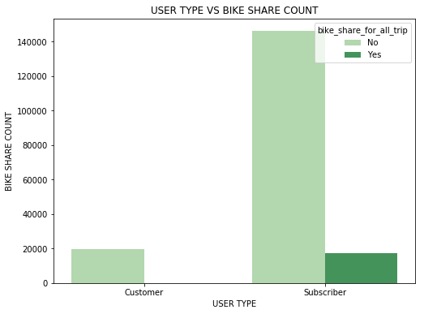

```python
plt.figure(figsize = [8, 6])
sb.countplot(data = df, x = 'user_type', hue = 'bike_share_for_all_trip', palette = 'Greens')
plt.xlabel('USER TYPE')
plt.ylabel('BIKE SHARE COUNT')
plt.title('USER TYPE VS BIKE SHARE COUNT')
plt.show()
```

Most riders customers and subscribers did not share their bikes.

### Talk about some of the relationships you observed in this part of the investigation. How did the feature(s) of interest vary with other features in the dataset?

> The trip duration depend mostly on age,user type and bike share, but it less likely depend on gender. The trip duration does not seem to depend on the start station id and end station id.

### Did you observe any interesting relationships between the other features (not the main feature(s) of interest)?

> I also looked into relationship between gender and age, bike share and age & gender and user type. It showed that other gender are likely to be older people, older riders are not likely to share their bikes and subscribers are likely to be the most riders in all genders.

## Multivariate Exploration

> I want to explore in this part of the analysis is how a categorical variable is related to two qualitative variables.

### How gender, trip duration and age are related.

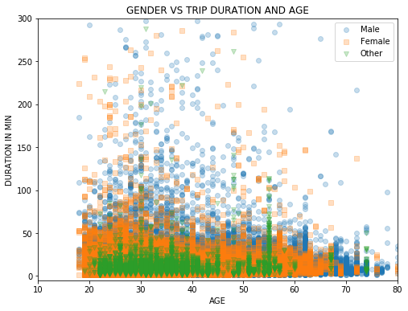

```python
plt.figure(figsize = [8, 6])
gender_markers = [['Male', 'o'],['Female', 's'],['Other', 'v']]
for gender, marker in gender_markers:
    df_gender = df[df['member_gender'] == gender]
    plt.scatter((df_gender['age']), df_gender['duration_min'], marker = marker, alpha=0.25)
plt.legend(['Male','Female','Other'])
plt.axis([10, 80, -5, 300 ])
plt.xlabel('AGE')
plt.ylabel('DURATION IN MIN')
plt.title('GENDER VS TRIP DURATION AND AGE')
plt.show()
```

The distribution is not clear enough.

I used facetgrid below for a clearer understanding.

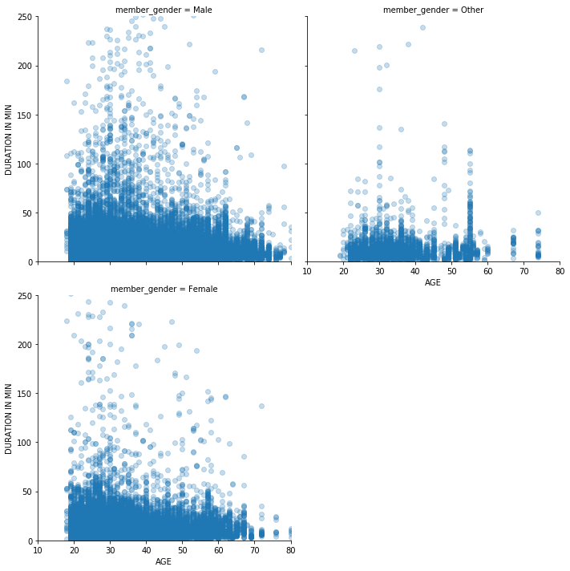

```python
genders = sb.FacetGrid(data = df, col = 'member_gender', col_wrap = 2, size = 5,xlim = [10, 80], ylim = [0, 250])
genders.map(plt.scatter, 'age', 'duration_min', alpha=0.25)
genders.set_xlabels('AGE')
genders.set_ylabels('DURATION IN MIN')
plt.show()
```

All these plots show that younger riders in all genders have longer trips compared to older people.

### How user type, trip duration and age are related.

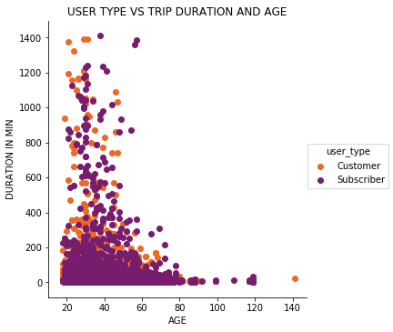

```python
plt.figure(figsize = [8, 6])
g=sb.FacetGrid(data=df,hue='user_type',size=5,palette='inferno_r')
g.map(plt.scatter,'age','duration_min')
plt.xlabel('AGE')
plt.ylabel('DURATION IN MIN')
plt.title('USER TYPE VS TRIP DURATION AND AGE')
g.add_legend()
```

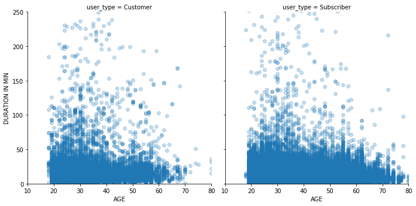

```python
user_types = sb.FacetGrid(data = df, col = 'user_type', col_wrap = 2, size = 5,xlim = [10, 80], ylim = [0, 250])
user_types.map(plt.scatter, 'age', 'duration_min', alpha=0.25)
user_types.set_xlabels('AGE')
user_types.set_ylabels('DURATION IN MIN')
plt.show()
```

All these plots above show that younger riders both customers and subscribers have longer trips compared to older people

### How user bike share, trip duration and age are related.

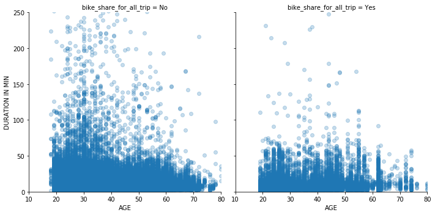

```python
bike_share = sb.FacetGrid(data = df, col = 'bike_share_for_all_trip', col_wrap = 2, size = 5,xlim = [10, 80], ylim = [0, 250])
bike_share.map(plt.scatter, 'age', 'duration_min', alpha=0.25)
bike_share.set_xlabels('AGE')
bike_share.set_ylabels('DURATION IN MIN')
plt.show()
```

## Conclusions

> The trip duration depend mostly on age,user type and bike share, but it less likely depend on gender. Younger riders are most likely to have the longest trip duration.